# Open the History of Philosophy with Data

Spark Li, hl3431

9/26/2021

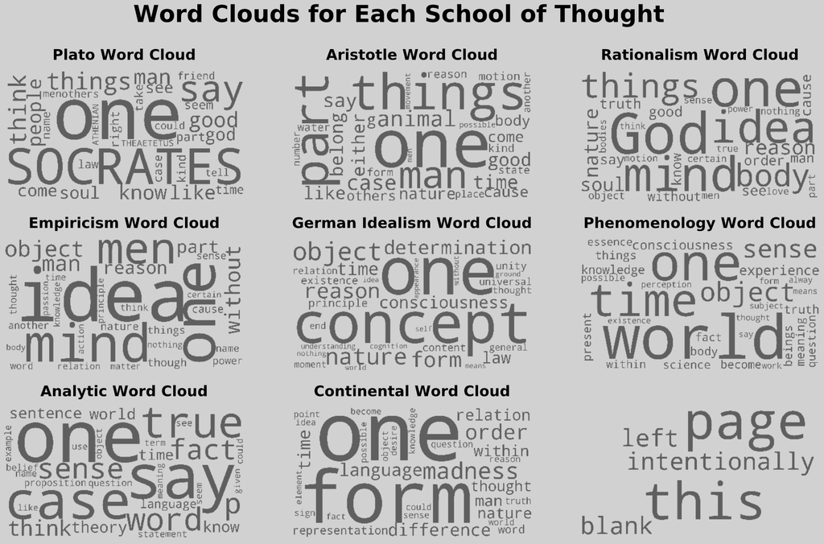

Source [Kourosh Alizadeh](https://github.com/kcalizadeh/phil_nlp)

Just imagine that: you are innocent about philosophy and one day you drop the flashcards of your girlfriend uses for preparing PPE quiz by accident. The flashcards are organized by each school of thought, and you have to recover them before she notices the condition.

It’s *Mission: Impossible*, isn’t it? Even though for those who knows a little about philosophy, it’s still *The Bourne Identity*. To be frank, that’s exactly my first impression of the work clouds at the beginning. Describe each school’s thought through word clouds? You’re asking a cook to make a Coq au vin based on Le Coq gaulois.

Notice that I’m not try to make objections on the common utility of word cloud. Word cloud is epochal, especially dealing with speeches or questionnaires, the data less academic and time dependent. The content of such text is less complicated. After removing stop words, the truths come out, in the order of significance. Nevertheless, for philosophy data, the utility of word cloud is suspect.

How do we open the history of philosophy with data?

This article aims to set up a connection between time/school and philosophy works for general audience. Do more recent works have a longer sentence on average than the classical ones? Do they criticize the classical or contemporary works more frequently? Is there a cluster of certain schools which compares works from others more? Wait a minute, and let me take you there.

|  | title | author | school | original_publication | corpus_edition | sentence | length |
| --- | --- | --- | --- | --- | --- | --- | --- |
| 1 | On The Principles Of Political Economy And Taxation | Ricardo | capitalism | 1817 | 2010 | taxes are not necessarily taxes on capital, because they are laid on capital; nor on income, because they are laid on income. | 125 |
| 2 | Theodicy | Leibniz | rationalism | 1710 | 2005 | here is another particular reason for the disorder apparent in that which concerns man. | 87 |
| 3 | Plato - Complete Works | Plato | plato | -350 | 1997 | even if somebody said all of them one after another that wouldn't be speech. | 76 |
| 4 | History Of Madness | Foucault | continental | 1961 | 2006 | curiously, it was only under the influence of the world of confinement in the seventeenth century that venereal disease became detached to some extent from this medical context, and like madness enter… | 241 |
| 5 | Aristotle - Complete Works | Aristotle | aristotle | -320 | 1991 | what occurs is comparable to the suffocation of a respiring animal by holding its mouth, for then the lung causes a heaving motion of this kind. | 144 |
| 6 | Philosophical Troubles | Kripke | analytic | 1975 | 2011 | since the police believe that there is a unique culprit, they are well aware that many of the suspects are in fact innocent. | 124 |
| 7 | History Of Madness | Foucault | continental | 1961 | 2006 | it was as though scandal had been expelled from those higher regions, above man, where he related to the divine through the incarnation, only to reappear with renewed force and teach an important less… | 271 |
| 8 | A Treatise Of Human Nature | Hume | empiricism | 1739 | 2003 | and even when this does not take place, we still feel a propensity to confound these ideas, though we a re not able fully to satisfy ourselves in that particular, nor find any thing invariable and uni… | 245 |
| 9 | Beyond Good And Evil | Nietzsche | nietzsche | 1886 | 2003 | but a curiosity like mine is once for all the most agreeable of vices pardon me! | 80 |
| 10 | The Logic Of Scientific Discovery | Popper | analytic | 1959 | 2002 | the preceding paragraph of this note may be taken as illustrating another rule of method (cf. | 93 |

[output cut: 140 more lines]

As the proverb goes, seeing is believing. For general audience, I believe it necessary to have a brief introduction to the dataset, via an interactive example. Hence, here I take a random sample containing 150 records from the original dataset, and you can have a surfing using the table above in any ways you prefer, but whatever the sample includes, it’s always not difficult to see that the length of sentence really varies. **This phenomenon motivates the article.** Compared with the abstract, sophisticated content, we’re more interested in the neat analysis related to concrete number.

Nevertheless, we need to dig into more details of the relations among author, school, and work firstly. It’s absolutely possible for one author to have multiple works; it’s also possible for one school to have multiple authors, but is there any author who corresponds to multiple schools? This sounds not possible, but we need to have a check. If there is, the case will be more complicated.

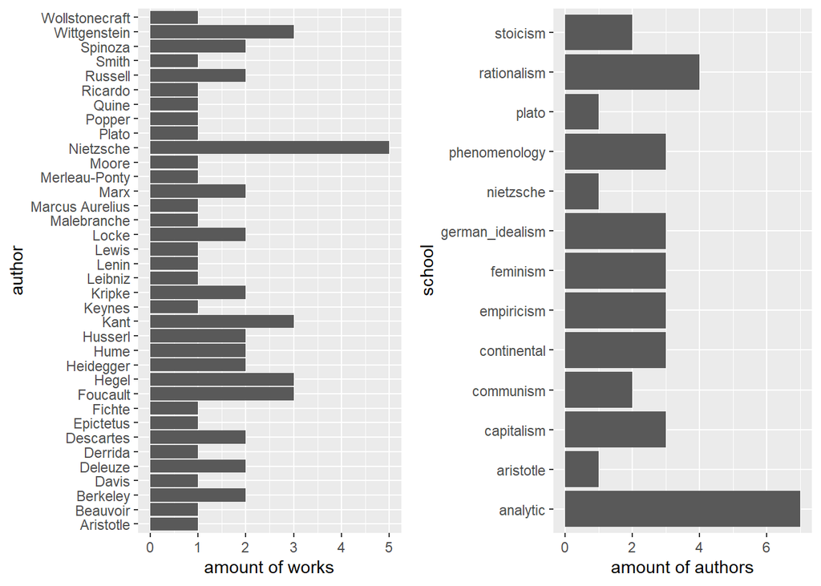

How many schools does each author correspond?

| author | school_amount |
| --- | --- |
| Aristotle | 1 |
| Beauvoir | 1 |
| Berkeley | 1 |
| Davis | 1 |
| Deleuze | 1 |
| Derrida | 1 |
| Descartes | 1 |
| Epictetus | 1 |
| Fichte | 1 |
| Foucault | 1 |
| Hegel | 1 |
| Heidegger | 1 |
| Hume | 1 |
| Husserl | 1 |
| Kant | 1 |
| Keynes | 1 |
| Kripke | 1 |
| Leibniz | 1 |
| Lenin | 1 |
| Lewis | 1 |
| Locke | 1 |
| Malebranche | 1 |
| Marcus Aurelius | 1 |
| Marx | 1 |
| Merleau-Ponty | 1 |
| Moore | 1 |
| Nietzsche | 1 |
| Plato | 1 |
| Popper | 1 |
| Quine | 1 |
| Ricardo | 1 |
| Russell | 1 |
| Smith | 1 |
| Spinoza | 1 |
| Wittgenstein | 1 |
| Wollstonecraft | 1 |

Fortunately, only author-work and school-author are one-to-multiple relation. All users in the database are only assigned in one school. Hence, We can jump to the next stage, **the first question**, do more recent works have a longer sentence on average than the classical ones? Before technical part, the first thing we need is to give a chronological definition of time. Usually there are three eras in the history of philosophy, Ancient era, Medieval era, and Modern era. Modern era is further divided into early modern era and late modern era. The latter sometimes is called 19th-century philosophy. All works after it is considered Contemporary philosophy. Based on this general chronology, this article divides all works into four categories: **Ancient** (all works before 5th century), **Medieval** (between 5th and 16th century), **Modern** (between 17th and 19th century), and **Contemporary** (after 19th century).

| author | title | original_publication | sentence_amount |
| --- | --- | --- | --- |
| Plato | Plato - Complete Works | -350 | 38366 |
| Aristotle | Aristotle - Complete Works | -320 | 48779 |
| Epictetus | Enchiridion | 125 | 323 |
| Marcus Aurelius | Meditations | 170 | 2212 |
| Descartes | Discourse On Method | 1637 | 340 |

Noticeably, the table above ordered by original publication year indicates that no work falls in **Medieval** category, so there will be only three categories for all analyses related time in this article.

Once category division is finished, the technical part comes. We want to know the general distribution of sentence length over the category. In order to check if there exists any trend, box plots with path line is our choice.

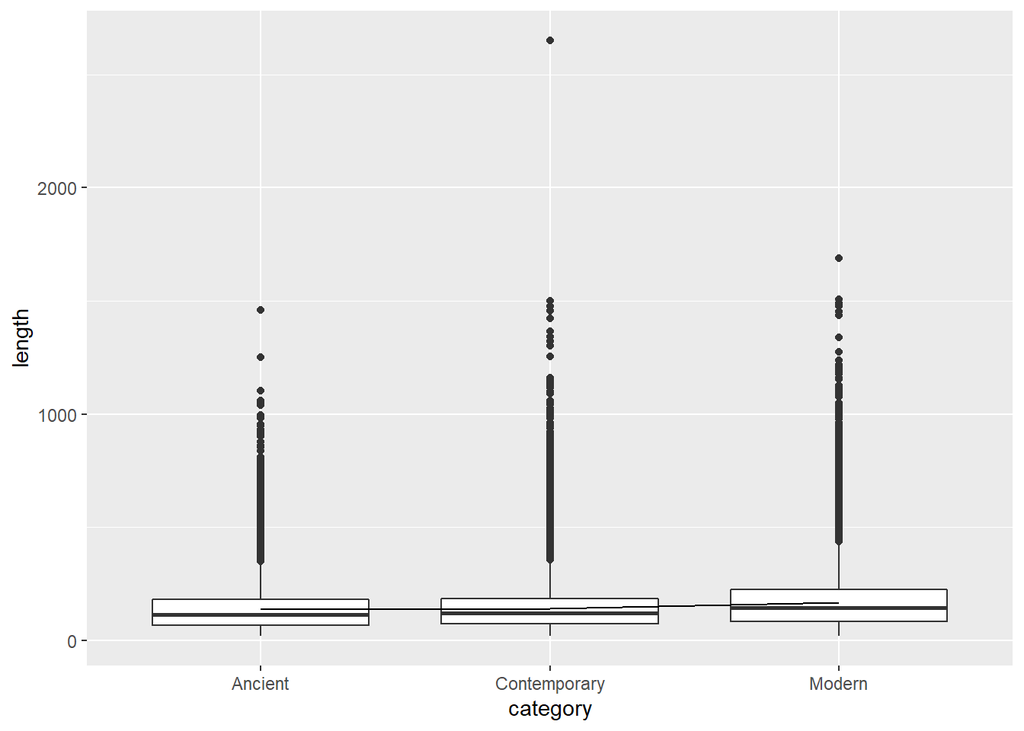

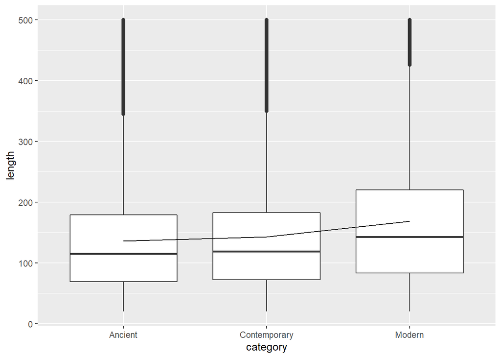

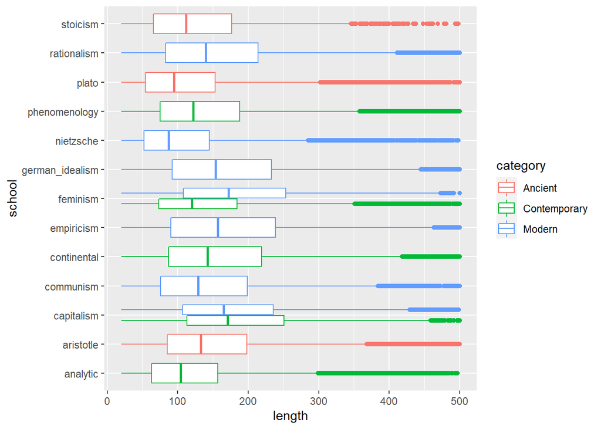

How many times does each era criticize other works?

| category | count_sum |
| --- | --- |
| Ancient | 160 |
| Contemporary | 5644 |
| Modern | 2096 |

**The last question** follows a similar process, but this time the comparison is more reliable because the data is more balanced when we discuss the school. Among all 13 schools, the analytic and continental school have authors who like mentioning other authors most; the phenomenology school forms a single cluster; the german_idealism, communism, and rationalism school composes the third cluster, while all the rest schools tend not to make a comparison or citation from others in their works.

How many times does each school criticize other works?

| school | count_sum |
| --- | --- |
| analytic | 2177 |
| continental | 2067 |
| phenomenology | 1203 |
| german_idealism | 692 |
| communism | 603 |
| rationalism | 438 |
| capitalism | 198 |
| feminism | 164 |
| nietzsche | 159 |
| aristotle | 96 |
| plato | 51 |
| empiricism | 39 |
| stoicism | 13 |